# Laboratory14

# Introduction

This lab is about practical SLR and uses 3 examples from the text to facilitate a review of some of the more important introductory concepts we need to know and understand when performing regression analysis.

There is also a `shiny` app to make run and learn some practical R skills to help you in your research and presentations.

The lab will inspect and develop formulae related to SLR. Most of the relationships will already be known by you.

You will need to perfect your knowledge in this area and be able to make your own R functions.

> 1. $SS_{XY}=\sum (X_i-\bar{X})(Y_i-\bar{Y})$
> 2. $\hat{\beta}_1= \frac{SS_{XY}}{SS_{XX}}$
> 3. $R^2 = \frac{MSS}{TSS}$

# Bayesian methods of estimation

The classical paradigm creates its formulae and interpretation around a particular conditioning:

$$X|\theta$$
where $\theta$ is the parameter and $X$ is the random variable representing possible data.

The Bayesian paradigm conditions differently. The theory is based around the following:

$$\theta|X$$

This means that the theory is developed very differently and the interpretation is also different.

The conditioning is obvious when we express the parameter and data in the Bayesian formula:

$$p(\theta|x)\propto p(\theta)f(x|\theta)$$

Fortunately many of the statistical techniques will find an application here.

Since some of the Bayesian tools are platform dependent I will use the R package `MCMCpack` to carry out our Bayesian analyses.

### Point estimate

Generally, Bayesians use the posterior mean as the point estimate. The reason for this is that the posterior mean minimizes the mean posterior squared error.

$$\hat{\theta} = E(\theta|x)=\mu_{\theta|x}$$

### Interval estimates

These come in many flavours but the common ones are quantile intervals, often called Bayesian Credible Intervals, BCI.

$$BCI=[\theta_{\alpha/2}, \theta_{1-\alpha/2}]$$
Or HDI, Highest Density Interval

$$HDI = [\theta_L, \theta_U]$$
The HDI is made so that the area above the interval is $1-\alpha$ but the distance $\theta_U-\theta_L$ is smallest.

### OJUICE example

The data is already available in the current package. We will first of all investigate the data using a [loess curve](https://en.wikipedia.org/wiki/Local_regression) this is known as **locally estimated scatterplot smoothing**. We use it to see what the data itself can tell us about the trend resident in the data and hence what model will be appropriate.

```r
data(ojuice)
head(ojuice)
```

| Run | SweetIndex | Pectin |
| --- | --- | --- |
| 1 | 5.2 | 220 |
| 2 | 5.5 | 227 |
| 3 | 6.0 | 259 |
| 4 | 5.9 | 210 |
| 5 | 5.8 | 224 |
| 6 | 6.0 | 215 |

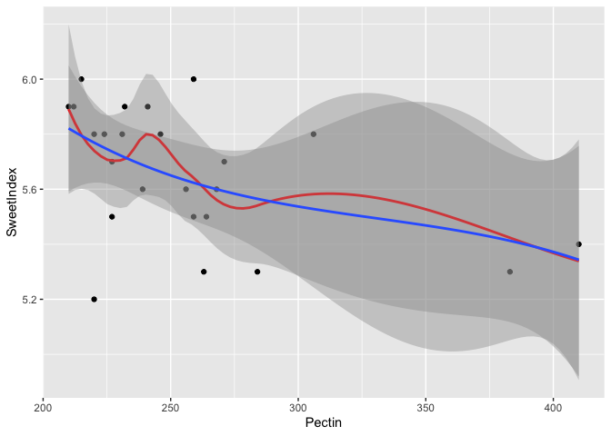

```r
library(ggplot2)

g <- ggplot(ojuice, aes(x=Pectin, y=SweetIndex))
g <- g + geom_point() + stat_smooth(method = "loess", formula = y~x, col = "Red")
g <- g +  stat_smooth( method = "lm", formula =y~x+I(x^2)+I(x^3))

print(g)
```